# Permutation Testing for Gene Enrichment Analysis

Mikhail Dozmorov

2025-10-22

# Introduction

This document demonstrates **permutation testing** for assessing gene enrichment on a specific chromosome. The key question is: **Are differentially expressed genes (DEGs) over-represented on a particular chromosome compared to what we’d expect by chance?**

Permutation testing is a non-parametric approach that: - Makes no assumptions about the underlying distribution - Creates an empirical null distribution through random sampling - Provides an alternative to parametric tests like Fisher’s exact test or Chi-square test

# Background: The Biological Question

Imagine you have:

- **200 total genes** in your study (e.g., from a gene expression experiment)
- **40 genes are located on Chromosome 1**, and 160 genes are on other chromosomes
- You identify **50 differentially expressed genes (DEGs)**
- Among these 50 DEGs, **15 are on Chromosome 1**

**Question:** Is Chromosome 1 enriched for DEGs, or could this pattern occur by random chance?

# Setting Up the Data

## Total Gene Population

First, we define the complete set of genes in our analysis, classified by their chromosomal location.

```r
# Create vector representing all genes in the study
# 40 genes on Chromosome 1, 160 on other chromosomes
a <- c(rep("On Other Chromosomes", 160), rep("On Chromosome 1", 40))

# Calculate totals
total.all   <- length(a)                        # Total genes (200)
total.chr   <- sum(a == "On Chromosome 1")      # Genes on Chromosome 1 (40)
total.other <- sum(a == "On Other Chromosomes") # Genes on other chromosomes (160)

# Verify totals add up correctly
all.equal(total.all, total.chr + total.other)
```

```
## [1] TRUE
```

```r
cat("Total genes:", total.all, "\n")
```

```
## Total genes: 200
```

```r
cat("Genes on Chromosome 1:", total.chr, "(", round(100*total.chr/total.all, 1), "%)\n")
```

```
## Genes on Chromosome 1: 40 ( 20 %)
```

```r
cat("Genes on other chromosomes:", total.other, "(", round(100*total.other/total.all, 1), "%)\n")
```

```
## Genes on other chromosomes: 160 ( 80 %)
```

## Differentially Expressed Genes (DEGs)

Next, we define which genes are differentially expressed in our experiment.

```r
# Selected genes (DEGs): 50 total
# 15 on Chromosome 1, 35 on other chromosomes
b <- c(rep("On Other Chromosomes", 35), rep("On Chromosome 1", 15))

selected.chr   <- sum(b == "On Chromosome 1")      # DEGs on Chromosome 1 (15)
selected.other <- sum(b == "On Other Chromosomes") # DEGs on other chromosomes (35)

cat("Total DEGs:", length(b), "\n")
```

```
## Total DEGs: 50
```

```r
cat("DEGs on Chromosome 1:", selected.chr, "(", round(100*selected.chr/length(b), 1), "%)\n")
```

```
## DEGs on Chromosome 1: 15 ( 30 %)
```

```r
cat("DEGs on other chromosomes:", selected.other, "(", round(100*selected.other/length(b), 1), "%)\n")
```

```
## DEGs on other chromosomes: 35 ( 70 %)
```

**Observation:** While only 20% of all genes are on Chromosome 1, **30% of DEGs** are on Chromosome 1. This suggests possible enrichment.

# Creating the Contingency Table

A 2×2 contingency table summarizes the relationship between chromosomal location and differential expression status.

```r
# Create 2x2 contingency table
#                    DEGs    not DEGs
# On Chromosome 1      15         25   (40 total)
# Other Chromosomes    35        125   (160 total)
#                     (50)      (150)  (200 total)

mtx <- matrix(c(selected.chr,
                selected.other,
                total.chr - selected.chr,
                total.other - selected.other),
              ncol = 2,
              dimnames = list(c("On Chromosome 1", "On Other Chromosomes"),
                              c("DEGs", "not DEGs")))

print(mtx)
```

```
##                      DEGs not DEGs
## On Chromosome 1        15       25
## On Other Chromosomes   35      125
```

```r
cat("\nTotal genes (verification):", sum(mtx), "\n")
```

```
##
## Total genes (verification): 200
```

**Reading the table:**

- **Row 1:** Of 40 genes on Chromosome 1, 15 are DEGs and 25 are not
- **Row 2:** Of 160 genes on other chromosomes, 35 are DEGs and 125 are not
- **Column 1:** Of 50 DEGs total, 15 are on Chromosome 1 and 35 are elsewhere
- **Column 2:** Of 150 non-DEGs, 25 are on Chromosome 1 and 125 are elsewhere

# Traditional Statistical Tests

## Fisher’s Exact Test

Fisher’s exact test calculates the exact probability of observing this contingency table (or more extreme) under the null hypothesis of independence.

```r
fisher_p <- fisher.test(mtx)$p.value
cat("Fisher's exact test p-value:", fisher_p, "\n")
```

```
## Fisher's exact test p-value: 0.06439416
```

```r
if (fisher_p < 0.05) {
  cat("Result: Significant enrichment detected (p < 0.05)\n")
} else {
  cat("Result: No significant enrichment (p >= 0.05)\n")
}
```

```
## Result: No significant enrichment (p >= 0.05)
```

**Interpretation:** Fisher’s exact test is the gold standard for small sample contingency tables and provides an exact p-value without relying on asymptotic approximations.

## Chi-Square Test

The Chi-square test of independence assesses whether the two categorical variables (chromosomal location and DEG status) are independent.

```r
chisq_p <- chisq.test(mtx)$p.value
cat("Chi-square test p-value:", chisq_p, "\n")
```

```
## Chi-square test p-value: 0.06619258
```

```r
if (chisq_p < 0.05) {
  cat("Result: Significant association detected (p < 0.05)\n")
} else {
  cat("Result: No significant association (p >= 0.05)\n")
}
```

```
## Result: No significant association (p >= 0.05)
```

**Note:** Chi-square test uses asymptotic approximations and may be less accurate for small sample sizes, but gives similar results to Fisher’s test in most cases.

# Permutation Testing Approach 1: Using Test Statistics

## Concept

Instead of relying on theoretical distributions, we create an **empirical null distribution** by: 1. Randomly selecting 50 genes (same size as our DEG set) from all 200 genes 2. Calculating the Chi-square statistic for each random selection 3. Repeating this process many times (10,000 permutations) 4. Comparing our observed statistic to this empirical distribution

**Null Hypothesis:** DEGs are randomly distributed with respect to chromosomal location.

## Implementation

```r
set.seed(2)  # For reproducibility

# Number of permutations
n <- 1:10000

# Observed test statistic from our actual data
estimate <- chisq.test(mtx)$statistic
cat("Observed Chi-square statistic:", round(estimate, 3), "\n\n")
```

```
## Observed Chi-square statistic: 3.375
```

```r
# Generate permutation distribution
estimate.rand <- sapply(n, function(x) {
  # Randomly select 50 genes from all 200 genes (without replacement)
  b.rand <- sample(a, size = length(b))

  # Count how many randomly selected genes are on each chromosome
  selected.chr.rand <- sum(b.rand == "On Chromosome 1")
  selected.other.rand <- sum(b.rand == "On Other Chromosomes")

  # Create permutation contingency table
  mtx.rand <- matrix(c(selected.chr.rand,
                       selected.other.rand,
                       total.chr - selected.chr.rand,
                       total.other - selected.other.rand),
                     ncol = 2)

  # Calculate Chi-square statistic for this permutation
  chisq.test(mtx.rand)$statistic
})

# Calculate permutation p-value
perm_p_chisq <- (sum(estimate.rand >= estimate) + 1) / (length(n) + 1)
cat("Permutation p-value (Chi-square method):", perm_p_chisq, "\n")
```

```
## Permutation p-value (Chi-square method): 0.06429357
```

## Visualizing the Permutation Distribution

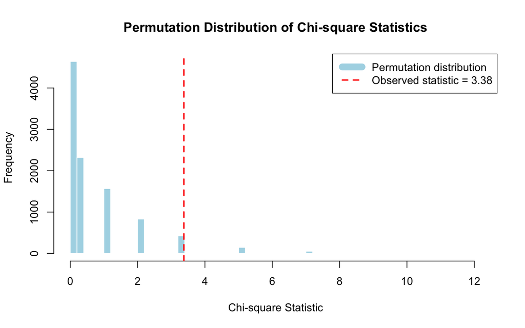

```r
# Plot histogram of permutation distribution
hist(estimate.rand,
     breaks = 50,
     main = "Permutation Distribution of Chi-square Statistics",
     xlab = "Chi-square Statistic",
     col = "lightblue",
     border = "white")

# Add observed statistic as vertical line
abline(v = estimate, col = "red", lwd = 2, lty = 2)

# Add legend
legend("topright",
       legend = c("Permutation distribution",
                  paste("Observed statistic =", round(estimate, 2))),
       col = c("lightblue", "red"),
       lwd = c(10, 2),
       lty = c(1, 2))

# Add text with p-value
text(x = max(estimate.rand) * 0.7,
     y = max(hist(estimate.rand, plot = FALSE)$counts) * 0.9,
     labels = paste("Permutation p-value =", perm_p_chisq),
     cex = 1.2)
```

**Interpretation:** The red line shows our observed Chi-square statistic. The permutation p-value represents the proportion of random permutations that produced a statistic as extreme or more extreme than what we observed.

# Permutation Testing Approach 2: Using Count Differences

## Concept

A simpler approach focuses directly on the **count** of DEGs on Chromosome 1:

- **Expected under null:** If DEGs are randomly distributed, we expect ~20% of 50 DEGs (= 10 genes) on Chromosome 1
- **Observed:** We actually see 15 DEGs on Chromosome 1
- **Question:** How often would we see 15 or more genes on Chromosome 1 by random chance?

## Implementation

```r
set.seed(1)  # For reproducibility
n <- 1:10000

# Observed count of DEGs on Chromosome 1
estimate <- selected.chr
cat("Observed DEGs on Chromosome 1:", estimate, "\n")
```

```
## Observed DEGs on Chromosome 1: 15
```

```r
cat("Expected DEGs on Chromosome 1 (under null):",
    round(length(b) * total.chr / total.all, 1), "\n\n")
```

```
## Expected DEGs on Chromosome 1 (under null): 10
```

```r
# Generate permutation distribution of counts
estimate.rand <- sapply(n, function(x) {
  # Randomly select 50 genes from all 200 genes
  b.rand <- sample(a, size = length(b))

  # Count how many are on Chromosome 1
  sum(b.rand == "On Chromosome 1")
})

# Calculate permutation p-value
# Count how often random selection gives >= observed count
perm_p_count <- sum(estimate.rand >= estimate) / length(n)
cat("Permutation p-value (count method):", perm_p_count, "\n")
```

```
## Permutation p-value (count method): 0.0355
```

## Visualizing the Count Distribution

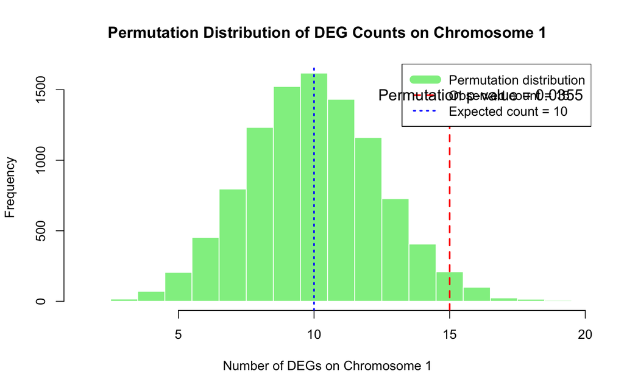

```r
# Plot histogram of permutation counts
hist(estimate.rand,
     breaks = seq(min(estimate.rand) - 0.5, max(estimate.rand) + 0.5, by = 1),
     main = "Permutation Distribution of DEG Counts on Chromosome 1",
     xlab = "Number of DEGs on Chromosome 1",
     col = "lightgreen",
     border = "white")

# Add observed count as vertical line
abline(v = estimate, col = "red", lwd = 2, lty = 2)

# Add expected count as vertical line
expected_count <- length(b) * total.chr / total.all
abline(v = expected_count, col = "blue", lwd = 2, lty = 3)

# Add legend
legend("topright",
       legend = c("Permutation distribution",
                  paste("Observed count =", estimate),
                  paste("Expected count =", round(expected_count, 1))),
       col = c("lightgreen", "red", "blue"),
       lwd = c(10, 2, 2),
       lty = c(1, 2, 3))

# Add text with p-value
text(x = max(estimate.rand) * 0.85,
     y = max(hist(estimate.rand, plot = FALSE)$counts) * 0.9,
     labels = paste("Permutation p-value =", perm_p_count),
     cex = 1.2)
```

**Interpretation:** The distribution shows what we’d expect by random chance. The red line (observed = 15) is notably higher than the blue line (expected ≈ 10), indicating enrichment.

# Comparing All Methods

```r
results <- data.frame(
  Method = c("Fisher's Exact Test",
             "Chi-square Test",
             "Permutation (Chi-square)",
             "Permutation (Count)"),
  P_Value = c(fisher_p, chisq_p, perm_p_chisq, perm_p_count),
  Significant = c(fisher_p < 0.05,
                  chisq_p < 0.05,
                  perm_p_chisq < 0.05,
                  perm_p_count < 0.05)
)

print(results)
```

```
##                     Method    P_Value Significant
## 1      Fisher's Exact Test 0.06439416       FALSE
## 2          Chi-square Test 0.06619258       FALSE
## 3 Permutation (Chi-square) 0.06429357       FALSE
## 4      Permutation (Count) 0.03550000        TRUE
```

## Summary Statistics

```r
cat("Summary of Permutation Distribution (Count Method):\n")
```

```
## Summary of Permutation Distribution (Count Method):
```

```r
cat("Mean:", round(mean(estimate.rand), 2), "\n")
```

```
## Mean: 9.98
```

```r
cat("Median:", median(estimate.rand), "\n")
```

```
## Median: 10
```

```r
cat("SD:", round(sd(estimate.rand), 2), "\n")
```

```
## SD: 2.46
```

```r
cat("95% CI:", quantile(estimate.rand, c(0.025, 0.975)), "\n")
```

```
## 95% CI: 5 15
```

```r
cat("\nObserved value:", estimate, "\n")
```

```
##
## Observed value: 15
```

```r
cat("Z-score:", round((estimate - mean(estimate.rand)) / sd(estimate.rand), 2), "\n")
```

```
## Z-score: 2.05
```

# Key Insights

## Advantages of Permutation Testing

1. **No distributional assumptions:** Works regardless of data distribution
2. **Exact for finite samples:** Especially valuable for small sample sizes
3. **Intuitive interpretation:** Directly answers “How often would we see this by chance?”
4. **Flexible:** Can use any test statistic, not just standard ones

## When to Use Permutation Tests

- Small sample sizes where asymptotic approximations may fail
- When distributional assumptions of parametric tests are violated
- When you need an exact test but Fisher’s exact is computationally prohibitive
- When you want to use a custom test statistic

## Computational Considerations

- **Number of permutations:** More permutations = more precise p-value
  - 1,000 permutations: precision ± 0.01
  - 10,000 permutations: precision ± 0.003
  - Use at least 1,000 for published work
- **Computational cost:** Increases linearly with number of permutations
- **Random seed:** Always set for reproducibility

# Conclusions

The permutation approach is particularly valuable because it: - Provides an independent validation of traditional tests - Offers intuitive visualization of the null distribution - Works well even with small sample sizes or violated assumptions